# Lab 10: Filtering Data

## Pick a dataset

Pick a dataset (feel free to delete the others from the Rmd file if you would like), and work on the instructions in the next section.

## Instructions

This lab is similar to the last. You’ll pick a dataset and then generate an analysis of that data using data visualizations. The difference here is that instead of a single plot, I would like you to construct 3-4 plots that together tell a linear story. Each plot should be separated by a sentence or two describing what the viewer should take away from the plot. Try to keep the plots similar in some way; perhaps each simply highlights a different subset of the data but has the same underlying layers.

Notice that each of the datasets for today are larger than you will probably be able to use. You will need to filter the data to a particular team, year, subset of curse words. You may further filter the data to highlight an even smaller subset of the data within each plot.

## Analysis

```
## # A tibble: 1,704 x 4
##             movie  type     word minutes_in
##             <chr> <chr>    <chr>      <dbl>
##  1 Reservoir Dogs  word     dick       0.40
##  2 Reservoir Dogs  word    dicks       0.43
##  3 Reservoir Dogs  word   fucked       0.55
##  4 Reservoir Dogs  word  fucking       0.61
##  5 Reservoir Dogs  word bullshit       0.61
##  6 Reservoir Dogs  word     fuck       0.66
##  7 Reservoir Dogs  word     shit       0.90
##  8 Reservoir Dogs  word     fuck       1.43
##  9 Reservoir Dogs  word    dicks       1.56
## 10 Reservoir Dogs  word     fuck       1.66
## # ... with 1,694 more rows
```

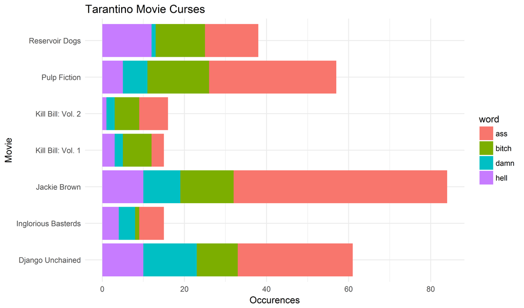

This plot shows the number of times the curse words ass, bitch, damn, and hell are said in Tarantino movies.

```
## # A tibble: 286 x 4
##             movie  type  word minutes_in
##             <chr> <chr> <chr>      <dbl>
##  1 Reservoir Dogs  word  hell       2.48
##  2 Reservoir Dogs  word   ass      22.80
##  3 Reservoir Dogs  word  hell      27.21
##  4 Reservoir Dogs  word  hell      29.18
##  5 Reservoir Dogs  word  hell      32.11
##  6 Reservoir Dogs  word  hell      39.46
##  7 Reservoir Dogs  word  hell      39.60
##  8 Reservoir Dogs  word bitch      39.88
##  9 Reservoir Dogs  word   ass      40.15
## 10 Reservoir Dogs  word   ass      40.30
## # ... with 276 more rows
```

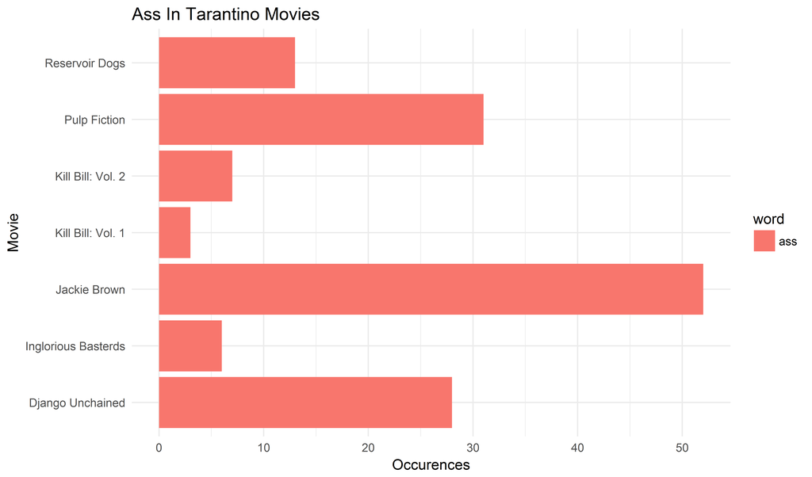

This plot shows the number of times the word ass is said in Tarantino movies.

```
## # A tibble: 286 x 4
##             movie  type  word minutes_in
##             <chr> <chr> <chr>      <dbl>
##  1 Reservoir Dogs  word  hell       2.48
##  2 Reservoir Dogs  word   ass      22.80
##  3 Reservoir Dogs  word  hell      27.21
##  4 Reservoir Dogs  word  hell      29.18
##  5 Reservoir Dogs  word  hell      32.11
##  6 Reservoir Dogs  word  hell      39.46
##  7 Reservoir Dogs  word  hell      39.60
##  8 Reservoir Dogs  word bitch      39.88
##  9 Reservoir Dogs  word   ass      40.15
## 10 Reservoir Dogs  word   ass      40.30
## # ... with 276 more rows
```

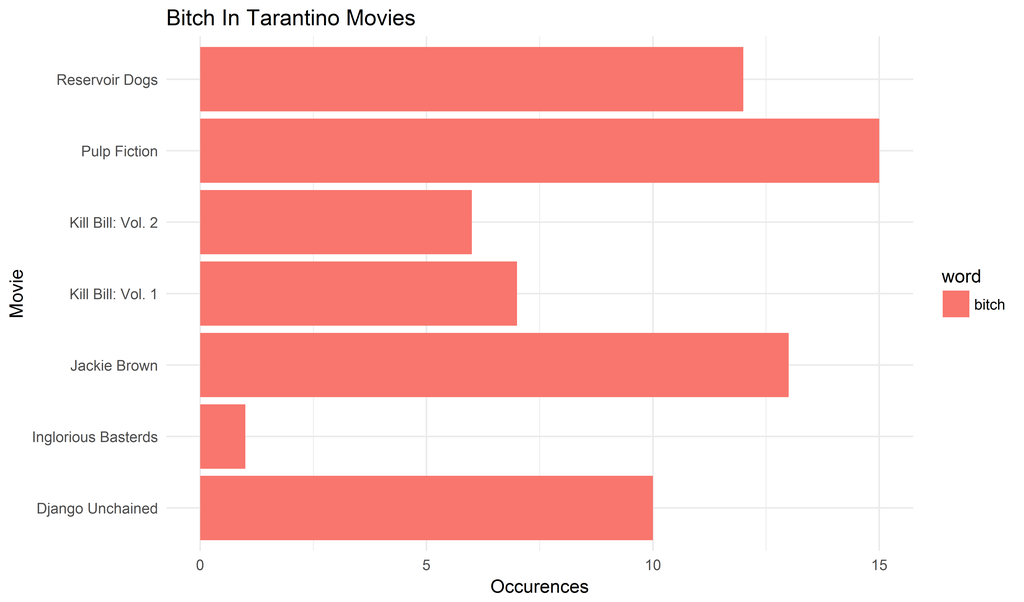

This plot shows the number of times the word bitch is said in Tarantino movies.

```
## # A tibble: 286 x 4
##             movie  type  word minutes_in
##             <chr> <chr> <chr>      <dbl>
##  1 Reservoir Dogs  word  hell       2.48
##  2 Reservoir Dogs  word   ass      22.80
##  3 Reservoir Dogs  word  hell      27.21
##  4 Reservoir Dogs  word  hell      29.18
##  5 Reservoir Dogs  word  hell      32.11
##  6 Reservoir Dogs  word  hell      39.46
##  7 Reservoir Dogs  word  hell      39.60
##  8 Reservoir Dogs  word bitch      39.88
##  9 Reservoir Dogs  word   ass      40.15
## 10 Reservoir Dogs  word   ass      40.30
## # ... with 276 more rows
```

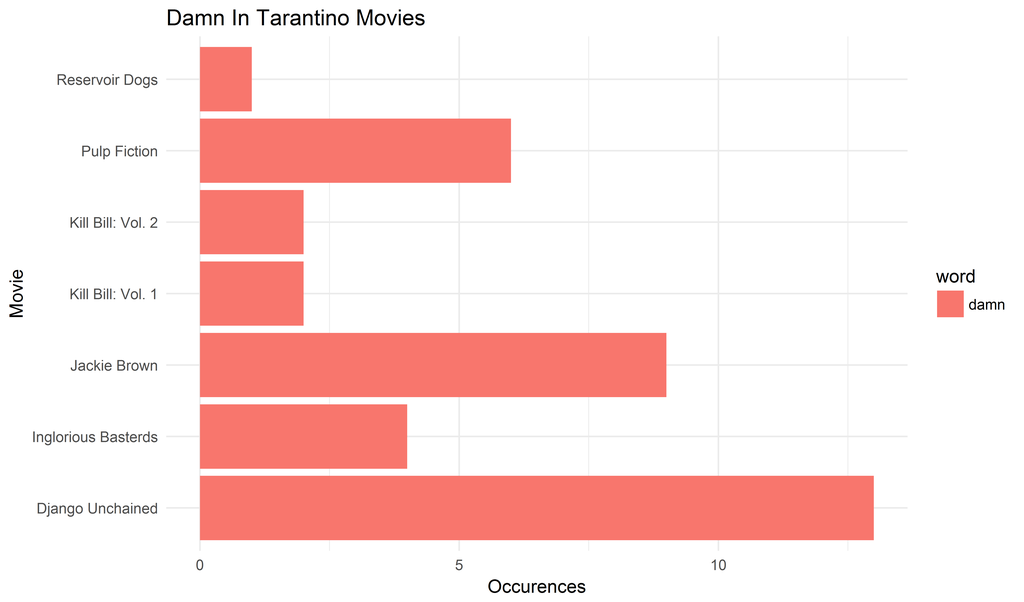

This plot shows the number of times the word damn is said in Tarantino movies.

```
## # A tibble: 286 x 4
##             movie  type  word minutes_in
##             <chr> <chr> <chr>      <dbl>
##  1 Reservoir Dogs  word  hell       2.48
##  2 Reservoir Dogs  word   ass      22.80
##  3 Reservoir Dogs  word  hell      27.21
##  4 Reservoir Dogs  word  hell      29.18
##  5 Reservoir Dogs  word  hell      32.11
##  6 Reservoir Dogs  word  hell      39.46
##  7 Reservoir Dogs  word  hell      39.60
##  8 Reservoir Dogs  word bitch      39.88
##  9 Reservoir Dogs  word   ass      40.15
## 10 Reservoir Dogs  word   ass      40.30
## # ... with 276 more rows
```

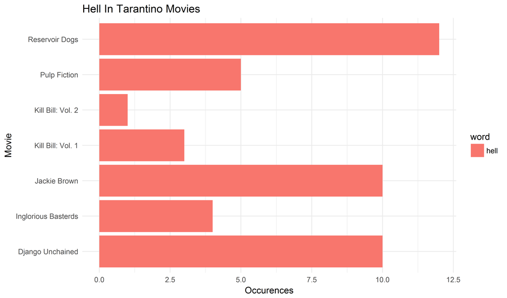

This plot shows the number of times the word hell is said in Tarantino movies.